# Spotify Data Analysis

Darren

2023-10-20

#Introduction Identifying Trends Within Chart-topping Spotify Songs

# Install Packages

```r
library(tidyverse)
library(dplyr)
library(ggplot2)
library(cluster)
```

# Read Data and Quick Overview

```r
Spotify <- read.csv("top10s.csv")
summary(Spotify)
```

```
##        X            title              artist           top.genre
##  Min.   :  1.0   Length:603         Length:603         Length:603
##  1st Qu.:151.5   Class :character   Class :character   Class :character
##  Median :302.0   Mode  :character   Mode  :character   Mode  :character
##  Mean   :302.0
##  3rd Qu.:452.5
##  Max.   :603.0
##       year           bpm             nrgy           dnce
##  Min.   :2010   Min.   :  0.0   Min.   : 0.0   Min.   : 0.00
##  1st Qu.:2013   1st Qu.:100.0   1st Qu.:61.0   1st Qu.:57.00
##  Median :2015   Median :120.0   Median :74.0   Median :66.00
##  Mean   :2015   Mean   :118.5   Mean   :70.5   Mean   :64.38
##  3rd Qu.:2017   3rd Qu.:129.0   3rd Qu.:82.0   3rd Qu.:73.00
##  Max.   :2019   Max.   :206.0   Max.   :98.0   Max.   :97.00
##        dB               live            val             dur
##  Min.   :-60.000   Min.   : 0.00   Min.   : 0.00   Min.   :134.0
##  1st Qu.: -6.000   1st Qu.: 9.00   1st Qu.:35.00   1st Qu.:202.0
##  Median : -5.000   Median :12.00   Median :52.00   Median :221.0
##  Mean   : -5.579   Mean   :17.77   Mean   :52.23   Mean   :224.7
##  3rd Qu.: -4.000   3rd Qu.:24.00   3rd Qu.:69.00   3rd Qu.:239.5
##  Max.   : -2.000   Max.   :74.00   Max.   :98.00   Max.   :424.0
##      acous            spch             pop
##  Min.   : 0.00   Min.   : 0.000   Min.   : 0.00
##  1st Qu.: 2.00   1st Qu.: 4.000   1st Qu.:60.00
##  Median : 6.00   Median : 5.000   Median :69.00
##  Mean   :14.33   Mean   : 8.358   Mean   :66.52
##  3rd Qu.:17.00   3rd Qu.: 9.000   3rd Qu.:76.00
##  Max.   :99.00   Max.   :48.000   Max.   :99.00
```

# Display Genre Distribution

```r
table(Spotify$top.genre)
```

```
##
##              acoustic pop              alaska indie           alternative r&b
##                         2                         1                         1
##                   art pop               atl hip hop          australian dance
##                         8                         5                         6
##        australian hip hop            australian pop             barbadian pop
##                         1                         5                        15
##               baroque pop               belgian edm                  big room
##                         2                         2                        10
##                  boy band              british soul                   brostep
##                        15                        11                         2
## canadian contemporary r&b          canadian hip hop            canadian latin
##                         9                         2                         1
##              canadian pop                 candy pop               celtic rock
##                        34                         2                         1
##               chicago rap             colombian pop                complextro
##                         1                         3                         6
##      contemporary country                 dance pop                danish pop
##                         1                       327                         1
##           detroit hip hop                 downtempo                       edm
##                         2                         2                         5
##                   electro             electro house           electronic trap
##                         2                         1                         2
##                electropop               escape room                  folk-pop
##                        13                         2                         2
##          french indie pop                   hip hop                   hip pop
##                         1                         4                         6
##                 hollywood                     house                 indie pop
##                         1                         1                         2
##   irish singer-songwriter                     latin              metropopolis
##                         1                         4                         1
##              moroccan pop                neo mellow            permanent wave
##                         1                         9                         4
##                       pop            tropical house
##                        60                         3
```

```r
Spotify <- Spotify %>%
  separate(top.genre, c("variable", "genre"), extra = "merge")
```

Group and simplify genres

```r
other <- c("complextro","downtempo","brostep","electro","electronic","escape","folk-pop","hollywood","house","irish","permanent","neo","metropolis","tropical")
Spotify$genre[Spotify$variable %in% "other"] <- "Other"
Spotify$genre[Spotify$variable == "hip"] <- "hip hop"
Spotify$genre[Spotify$variable == "latin"] <- "latin"
Spotify$genre[Spotify$variable == "boy"]  <- "pop"
Spotify$genre[Spotify$variable == "french"]  <- "pop"
Spotify$genre[Spotify$variable == "electropop"]  <- "pop"
Spotify$genre[Spotify$variable == "pop"]  <- "pop"
Spotify$genre[Spotify$genre == "contemporary r&b"] <- "r&b"
Spotify$genre[Spotify$genre == "room"] <- "Other"
table(Spotify$genre)
```

```
##
##           country             dance               edm           hip hop
##                 1                 6                 2                20
##             house             indie             latin            mellow
##                 4                 1                 5                 9
##             Other               pop               r&b               rap
##                12               493                10                 1
##              rock singer-songwriter              soul              trap
##                 1                 1                11                 2
##              wave
##                 4
```

```r
miss <- colSums(is.na(Spotify))
print(miss[miss>0])
```

```
## genre
##    20
```

```r
Spotify <-na.omit(Spotify)
```

# Data Exploration

Questions: 1. Which artist has the most popular song from 2010 to 2019? According to the code, the most popular song from 2010 to 2019 is “Memories by Maroon 5.” 2. Which artist has the most popular songs from 2010 to 2019? According to the graph, the artist with the most popular songs from 2010 to 2019 is Katy Perry with 17. 3. Which artist has the most popular songs within 2019? According to the graph, the artist with the most popular songs within 2019 is Ed Sheeran with 5.

```r
mostPopular <- Spotify %>%
  arrange(desc(pop)) %>%
  group_by(artist)
mostPopular
```

```
## # A tibble: 583 × 16
## # Groups:   artist [175]
##        X title   artist variable genre  year   bpm  nrgy  dnce    dB  live   val
##    <int> <chr>   <chr>  <chr>    <chr> <int> <int> <int> <int> <int> <int> <int>
##  1   573 "Memor… Maroo… pop      pop    2019    91    32    76    -7     8    57
##  2   574 "Lose … Selen… dance    pop    2019   102    34    51    -9    21     9
##  3   575 "Someo… Lewis… pop      pop    2019   110    41    50    -6    11    45
##  4   576 "Se\xf… Shawn… canadian pop    2019   117    54    76    -6     9    75
##  5   577 "How D… Sam S… pop      pop    2019   111    68    48    -5     8    35
##  6   578 "South… Ed Sh… pop      pop    2019    98    62    86    -6     9    67
##  7   579 "Tramp… SHAED  electro… pop    2019   127    46    62    -6    14    50
##  8   581 "Truth… Lizzo  escape   Other  2019   158    62    72    -3    12    41
##  9   582 "Good … Lizzo  escape   Other  2019    96    89    67    -3    74    48
## 10   140 "Under… Kelly… dance    pop    2013   160    81    51    -5    21    69
## # ℹ 573 more rows
## # ℹ 4 more variables: dur <int>, acous <int>, spch <int>, pop <int>
```

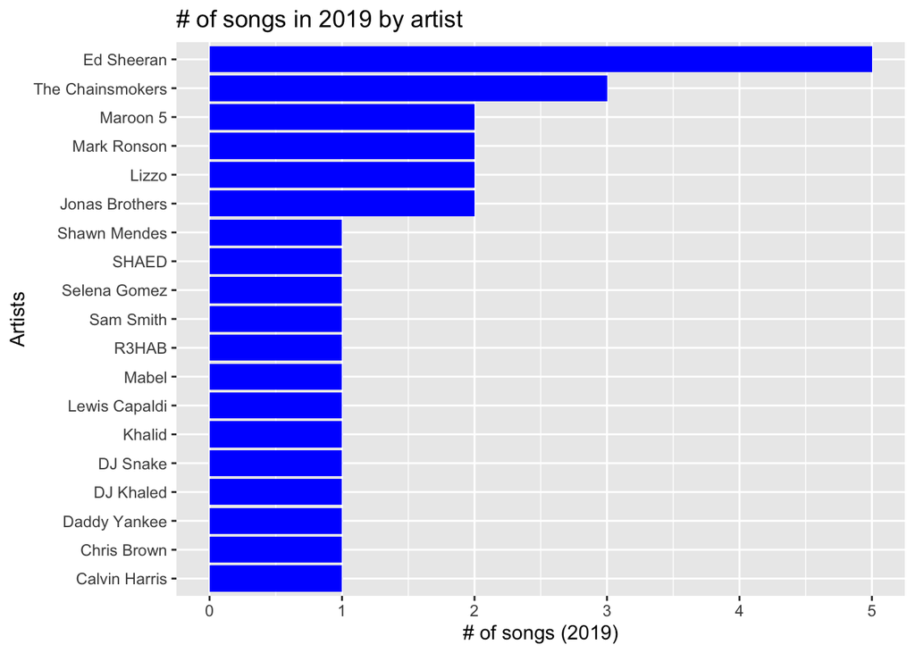

```r
mostPopularPlot <- mostPopular %>%
  filter(year == 2019) %>%
  count(artist) %>%
  ggplot(aes(x = reorder(artist, n), y = n)) + geom_col(fill = "blue") + coord_flip() + labs(title = "# of songs in 2019 by artist", x = "Artists", y = "# of songs (2019)")
mostPopularPlot
```

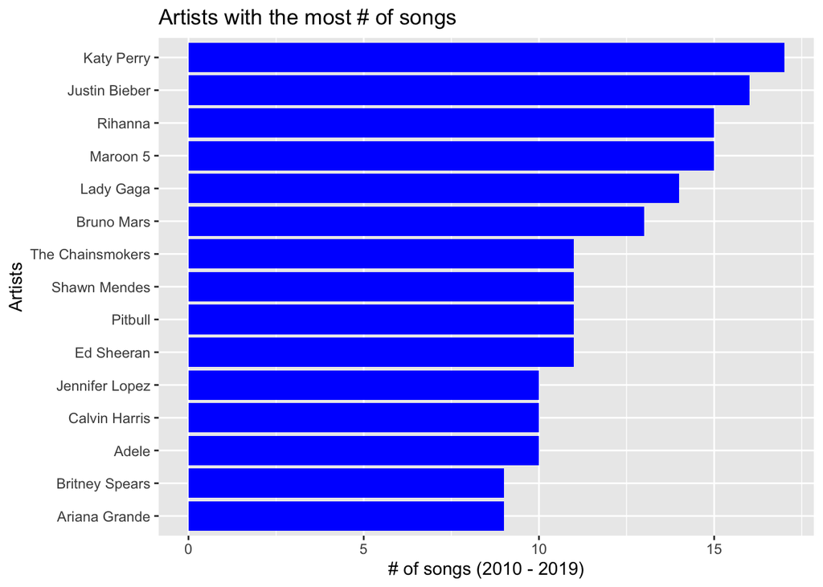

```r
mostPopularArtist <- mostPopular %>%
  count(artist) %>%
  arrange(desc(n))

mostPopularArtistPlot <- mostPopularArtist %>%
  head(15) %>%
  ggplot(aes(x = reorder(artist, n), y = n)) + geom_col(fill = "blue") + coord_flip() + labs(title = "Artists with the most # of songs", x = "Artists", y = "# of songs (2010 - 2019)")
mostPopularArtistPlot
```

# Measure Analysis

1. Duration Analysis Most songs have a duration between 3-4 minutes. Many outliers in the pop genre, so we look at min/max duration The shortest song is “Mark My Words by Justin Bieber” at 134 seconds and the longest song is “TKO by Justin Timberlake” at 424 seconds. Both are coincidentally by Justins.

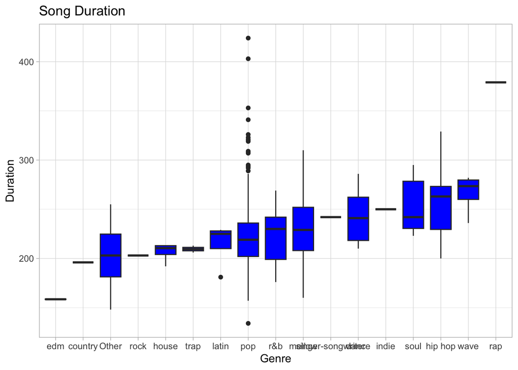

```r
durationPlot <- Spotify %>%
  ggplot(aes(x = reorder(genre, dur), y = dur)) + geom_boxplot(fill = "blue") + labs(title = "Song Duration", x = "Genre", y = "Duration") + theme_light()
durationPlot
```

```r
popdf <- Spotify %>%
  filter(genre == "pop")

Q1 <- summary(popdf$dur)[2]
Q3 <- summary(popdf$dur)[4]

highOutlier <- popdf %>%
  filter(dur > Q3 + 1.5 * IQR(dur)) %>%
  arrange(desc(dur)) %>%
  select(artist, title, dur)
highOutlier
```

```
##                     artist
## 1        Justin Timberlake
## 2   Florence + The Machine
## 3        Justin Timberlake
## 4             Harry Styles
## 5        Justin Timberlake
## 6               Beyonc\xe9
## 7                Lady Gaga
## 8                  Rihanna
## 9               Beyonc\xe9
## 10              Ed Sheeran
## 11     The Black Eyed Peas
## 12               Lady Gaga
## 13               Lady Gaga
## 14       Justin Timberlake
```

[output cut: 78 more lines]

```r
lowOutlier <- popdf %>%
  filter(dur < Q1 - 1.5 * IQR(dur)) %>%
  select(artist, title, dur)
lowOutlier
```

```
##          artist         title dur
## 1 Justin Bieber Mark My Words 134
```

```r
max <- popdf %>%
  filter(dur == max(dur)) %>%
  select(artist, title, dur)
max
```

```
##              artist title dur
## 1 Justin Timberlake   TKO 424
```

```r
min <- popdf %>%
  filter(dur == min(dur)) %>%
  select(artist, title, dur)
min
```

```
##          artist         title dur
## 1 Justin Bieber Mark My Words 134
```

2. BPM Analysis Most songs tend to be between 100 to 150 bpm, but there are a few outliers that are above 200 bpm. These include: “How Ya Doin’? by Little Mix,” “L.A LOVE (la la) by Fergie,” and “FourFiveSeconds by Rihanna.”

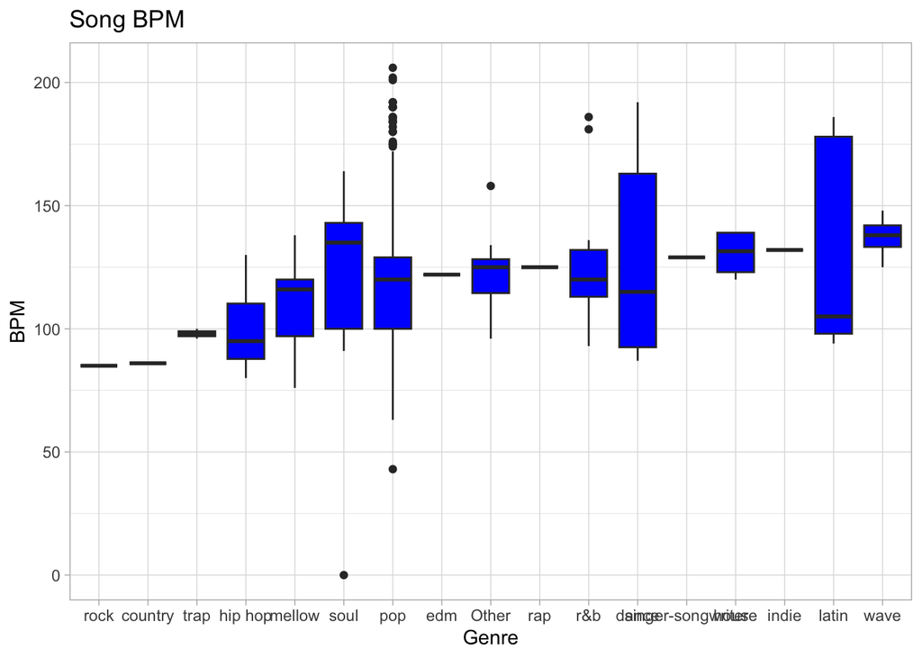

```r
bpm <- Spotify %>%
  ggplot(aes(x = reorder(genre, bpm), y = bpm)) + geom_boxplot(fill = "blue") + labs(title = "Song BPM", x = "Genre", y = "BPM") + theme_light()
bpm
```

```r
bpmMax <- Spotify %>%
  filter(bpm >= 200) %>%
  select(artist, title, bpm)
bpmMax
```

```
##       artist                               title bpm
## 1 Little Mix How Ya Doin'? (feat. Missy Elliott) 201
## 2    Rihanna                     FourFiveSeconds 206
## 3     Fergie                    L.A.LOVE (la la) 202
```

3. Energy Analysis From the data, we can see that pop, dance, latin, trap, house, rock, and others all have a median above 75 energy rating, meaning that those genres tend to have a higher energy. Next we can find the artists that have the highest energy which are: Martin Solveig and the Jonas Brothers at 98.

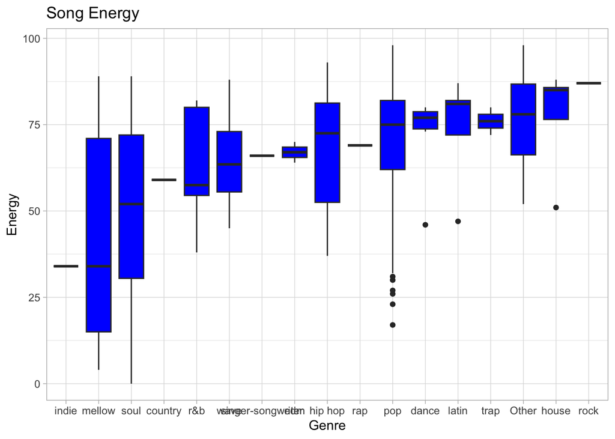

```r
energy <- Spotify %>%
  ggplot(aes(x = reorder(genre, nrgy), y = nrgy)) + geom_boxplot(fill = "blue") + labs(title = "Song Energy", x = "Genre", y = "Energy") + theme_light()
energy
```

```r
mostEnergy <- Spotify %>%
  arrange(desc(nrgy)) %>%
  select(artist, title, nrgy)
mostEnergy
```

```
##                       artist
## 1             Martin Solveig
## 2             Jonas Brothers
## 3                    Pitbull
## 4              Avril Lavigne
## 5                OneRepublic
## 6               Tinie Tempah
## 7               Tinie Tempah
## 8                 Little Mix
## 9        5 Seconds of Summer
## 10            Jennifer Lopez
## 11                      DNCE
## 12          Enrique Iglesias
## 13                   Pitbull
## 14            Kelly Clarkson
```

[output cut: 1737 more lines]

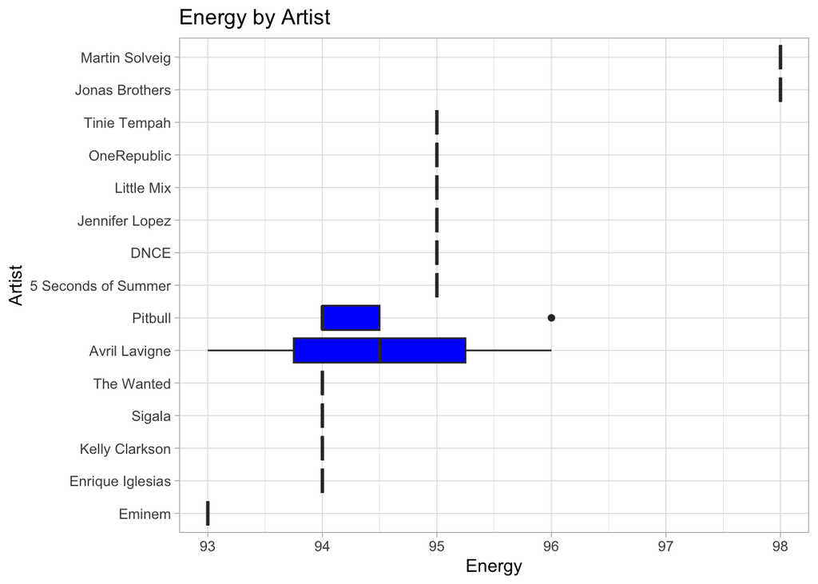

```r
artistEnergy <- mostEnergy %>%
  head(20) %>%
  ggplot(aes(x = reorder(artist, nrgy), y = nrgy)) + geom_boxplot(fill = "blue") + labs(title = "Energy by Artist", x = "Artist", y = "Energy") + coord_flip() + theme_light()
artistEnergy
```

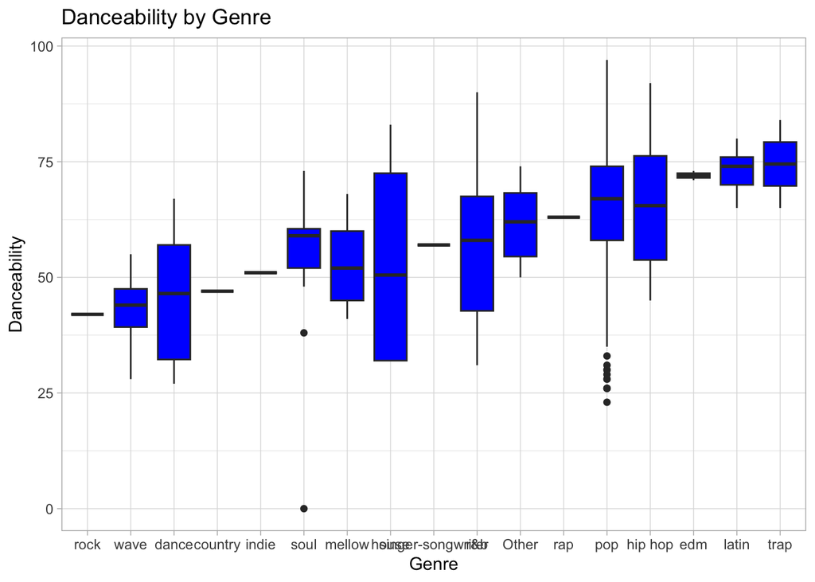

```r
danceability <- Spotify %>%
  ggplot(aes(x = reorder(genre, dnce), y = dnce)) + geom_boxplot(fill = "blue") + labs(title = "Danceability by Genre", x = "Genre", y = "Danceability") + theme_light()
danceability
```

```r
mostDanceable <- Spotify %>%
  arrange((desc(dnce))) %>%
  select(artist, title, dnce)
mostDanceable
```

```
##                       artist
## 1               Selena Gomez
## 2                    Cardi B
## 3                Nicki Minaj
## 4          Pharrell Williams
## 5             Meghan Trainor
## 6              Missy Elliott
## 7                    Cardi B
## 8                    N.E.R.D
## 9                Iggy Azalea
## 10           Jennifer Hudson
## 11                    Khalid
## 12             Fifth Harmony
## 13              Gwen Stefani
## 14                Bruno Mars
```

[output cut: 1737 more lines]

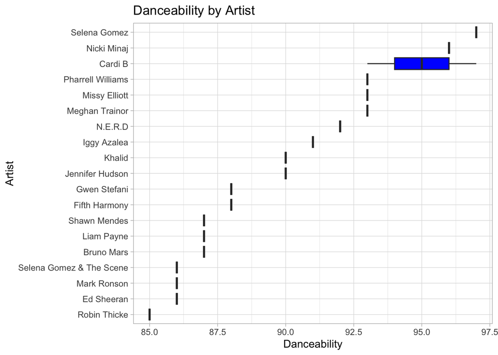

```r
artistDanceability <- mostDanceable %>%
  head(20) %>%
  ggplot(aes(x = reorder(artist, dnce), y = dnce)) + geom_boxplot(fill = "blue") + labs(title = "Danceability by Artist", x = "Artist", y = "Danceability") + coord_flip() + theme_light()
artistDanceability
```

5. Positivity Analysis The genre with the highest median positivity is Latin but the songs with the highest positivity are: “Mmm Yeah by Austin Mahone” and “There’s Nothing Holdin’ Me Back.”

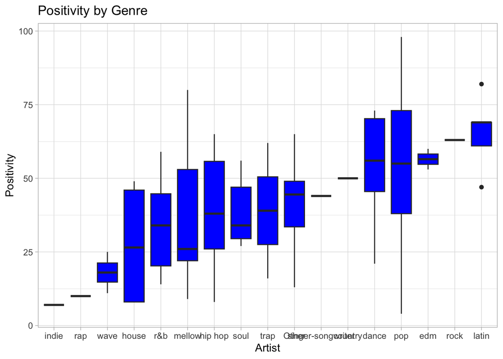

```r
positivity <- Spotify %>%
  filter(!dB == -60) %>%
  ggplot(aes(x = reorder(genre, val), y = val)) + geom_boxplot(fill = "blue") + labs(title = "Positivity by Genre", x = "Artist", y = "Positivity") + theme_light()
positivity
```

```r
mostPositivity <- Spotify %>%
  arrange(desc(val)) %>%
  select(artist, title, val)
mostPositivity
```

```
##                       artist
## 1              Austin Mahone
## 2               Shawn Mendes
## 3          Pharrell Williams
## 4             Meghan Trainor
## 5                    Pitbull
## 6             Meghan Trainor
## 7             Jonas Brothers
## 8               Taylor Swift
## 9                 Bruno Mars
## 10                Ed Sheeran
## 11                    MAGIC!
## 12               Mark Ronson
## 13                   Pitbull
## 14                Ed Sheeran
```

[output cut: 1737 more lines]

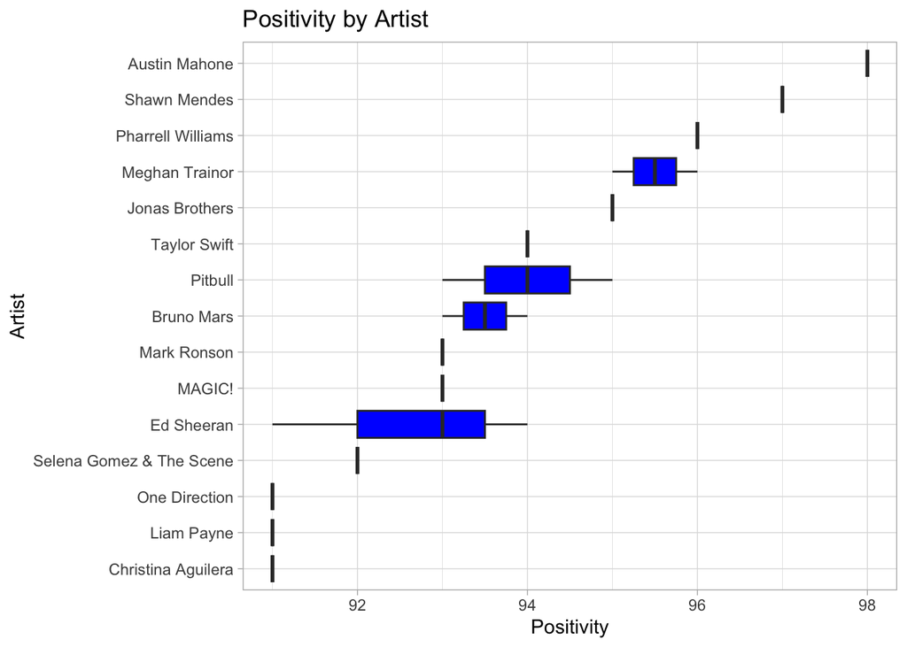

```r
artistValue <- mostPositivity %>%
  head(20) %>%
  ggplot(aes(x = reorder(artist, val), y = val)) + geom_boxplot(fill = "blue") + labs(title = "Positivity by Artist", x = "Artist", y = "Positivity") + coord_flip() + theme_light()
artistValue
```

6. Speech Analysis Before running the code, my guess is that Rap will have the highest median speech value. Running the code confirms this.

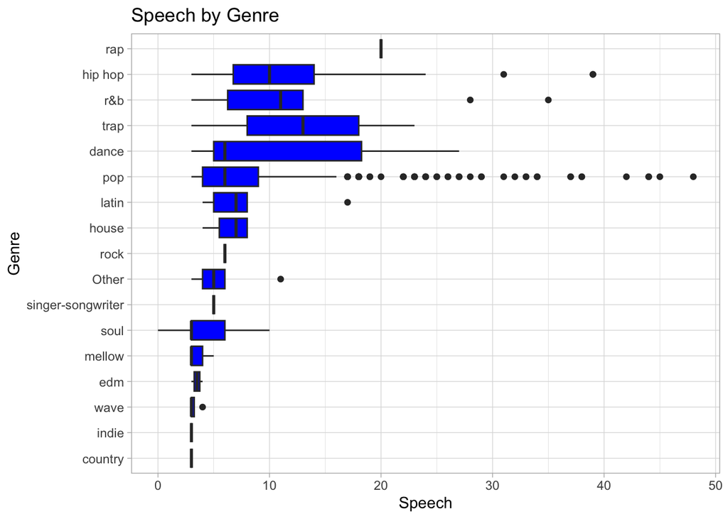

```r
speech <- Spotify %>%
  ggplot(aes(x = reorder(genre, spch), y = spch)) + geom_boxplot(fill = "blue") + labs(title = "Speech by Genre", x = "Genre", y = "Speech") + coord_flip() + theme_light()
speech
```